# How to build a complicated, layered graphic

```r
library(tidyverse)
library(knitr)
```

# Charles Minard’s map of Napoleon’s disastrous Russian campaign of 1812

[figure not shown]

[“Carte figurative des pertes successives en hommes de l’Armee Français dans la campagne de Russe 1812–1813” by Charles Joseph Minard](https://en.wikipedia.org/wiki/Charles_Joseph_Minard)

The graphic is notable for its representation in two dimensions of six types of data: the number of Napoleon’s troops; distance; temperature; the latitude and longitude; direction of travel; and location relative to specific dates.[^1]

# Building Minard’s map in R

```r
# get data on troop movements and city names
troops <- read_table("data/minard-troops.txt")
cities <- read_table("data/minard-cities.txt")
troops
```

```
## # A tibble: 51 x 5
##     long   lat survivors direction group
##    <dbl> <dbl>     <int>     <chr> <int>
##  1  24.0  54.9    340000         A     1
##  2  24.5  55.0    340000         A     1
##  3  25.5  54.5    340000         A     1
##  4  26.0  54.7    320000         A     1
##  5  27.0  54.8    300000         A     1
##  6  28.0  54.9    280000         A     1
##  7  28.5  55.0    240000         A     1
##  8  29.0  55.1    210000         A     1
##  9  30.0  55.2    180000         A     1
## 10  30.3  55.3    175000         A     1
## # ... with 41 more rows
```

```r
cities
```

```
## # A tibble: 20 x 3
##     long   lat           city
##    <dbl> <dbl>          <chr>
##  1  24.0  55.0          Kowno
##  2  25.3  54.7          Wilna
##  3  26.4  54.4       Smorgoni
##  4  26.8  54.3      Moiodexno
##  5  27.7  55.2      Gloubokoe
##  6  27.6  53.9          Minsk
##  7  28.5  54.3     Studienska
##  8  28.7  55.5        Polotzk
##  9  29.2  54.4           Bobr
## 10  30.2  55.3        Witebsk
## 11  30.4  54.5         Orscha
## 12  30.4  53.9        Mohilow
## 13  32.0  54.8       Smolensk
## 14  33.2  54.9    Dorogobouge
## 15  34.3  55.2          Wixma
## 16  34.4  55.5          Chjat
## 17  36.0  55.5        Mojaisk
## 18  37.6  55.8         Moscou
## 19  36.6  55.3      Tarantino
## 20  36.5  55.0 Malo-Jarosewii
```

## Exercise: Define the grammar of graphics for this graph

**Click here for solution**

- Layer
  - Data - `troops`
  - Mapping
    - $x$ and $y$ - troop position (`lat` and `long`)
    - Size - `survivors`
    - Color - `direction`
  - Statistical transformation (stat) - `identity`
  - Geometric object (geom) - `path`
  - Position adjustment (position) - none
- Layer
  - Data - `cities`
  - Mapping
    - $x$ and $y$ - city position (`lat` and `long`)
    - Label - `city`
  - Statistical transformation (stat) - `identity`
  - Geometric object (geom) - `text`
  - Position adjustment (position) - none
- Scale
  - Size - range of widths for troop `path`
  - Color - colors to indicate advancing or retreating troops
- Coordinate system - map projection (Mercator or something else)
- Faceting - none

## Write the R code

First we want to build the layer for the troop movement:

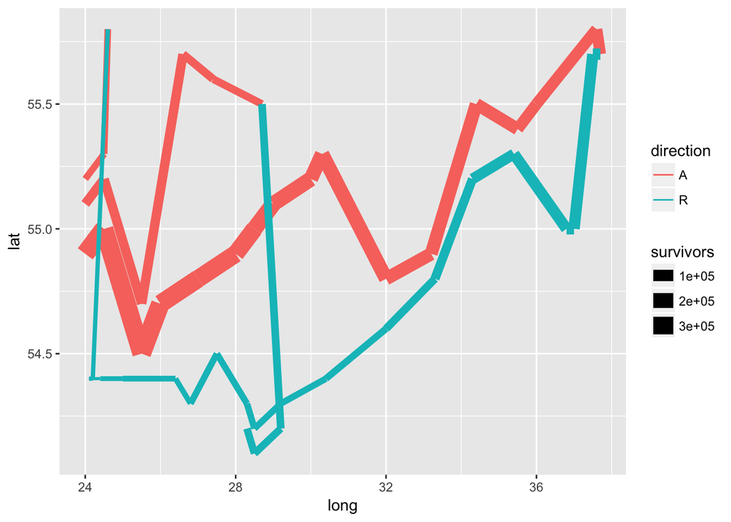

```r
plot_troops <- ggplot(data = troops, mapping = aes(x = long, y = lat)) +
  geom_path(aes(size = survivors,
                color = direction,
                group = group))
plot_troops
```

Next let’s add the cities layer:

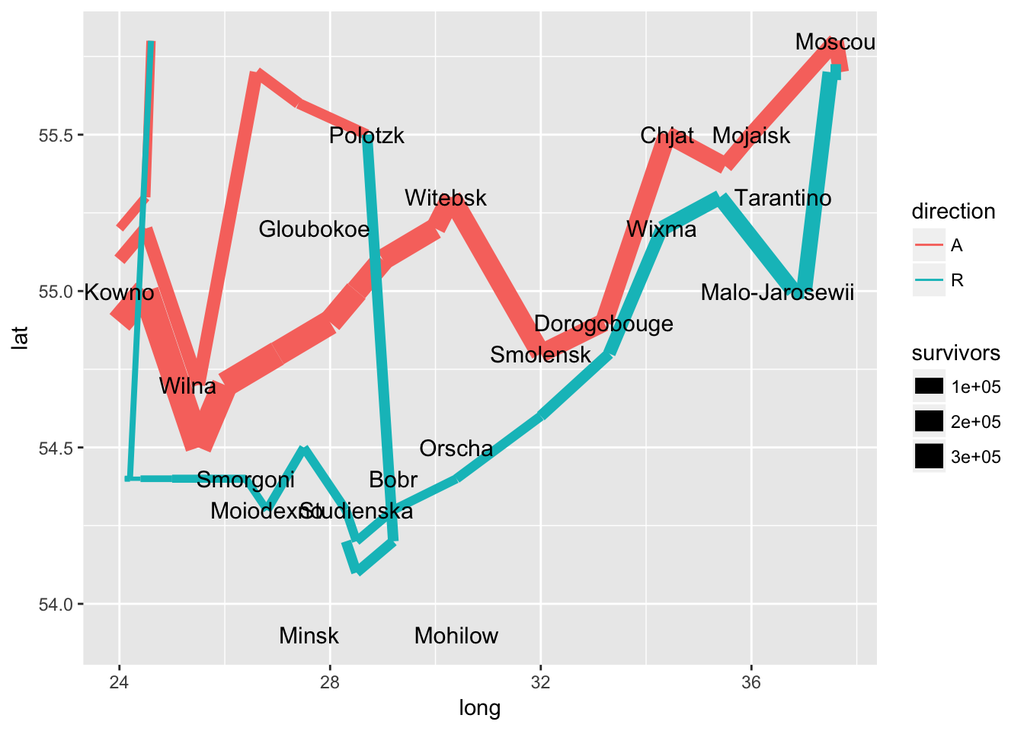

```r
plot_both <- plot_troops +
  geom_text(data = cities, mapping = aes(label = city), size = 4)
plot_both
```

Now that the basic information is on there, we want to clean up the graph and polish the visualization by:

- Adjusting the size scale aesthetics for troop movement to better highlight the loss of troops over the campaign.
- Change the default colors to mimic Minard’s original grey and tan palette.
- Change the coordinate system to a map-based system that draws the $x$ and $y$ axes at equal intervals.
- Give the map a title and remove the axis labels.

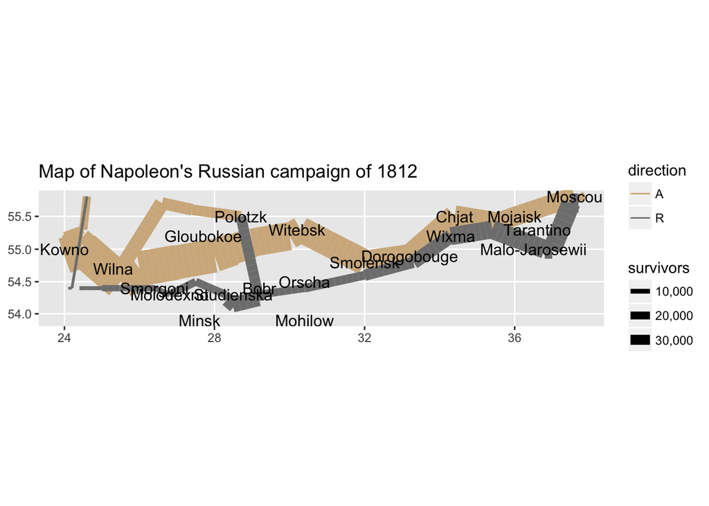

```r
plot_polished <- plot_both +
  scale_size(range = c(0, 12),
             breaks = c(10000, 20000, 30000),
             labels = c("10,000", "20,000", "30,000")) +
  scale_color_manual(values = c("tan", "grey50")) +
  coord_map() +
  labs(title = "Map of Napoleon's Russian campaign of 1812",
       x = NULL,
       y = NULL)
plot_polished
```

Finally we can change the default `ggplot` theme to remove the background and grid lines, as well as the legend:

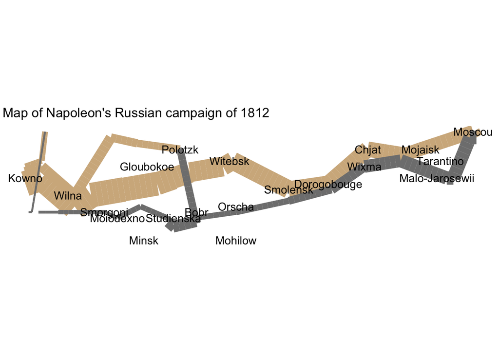

[output not shown]

[output not shown]

[output not shown]

[output cut: 11 more lines]

[output not shown]

```r
plot_polished +
  theme_void() +
  theme(legend.position = "none")
```

[^1]: This exercise is drawn from [Wickham, Hadley. (2010) “A Layered Grammar of Graphics”. *Journal of Computational and Graphical Statistics*, 19(1).](http://www.jstor.org.proxy.uchicago.edu/stable/25651297)

This work is licensed under the [CC BY-NC 4.0 Creative Commons License](http://creativecommons.org/licenses/by-nc/4.0/).